# Optimal Treatment Analysis

## Outcome Variable

**Outcome Variable:** haz

## Predictor Variables

**Intervention Variable:** perdiar24

**Adjustment Set:**

- arm
- sex
- meducyrs
- feducyrs
- hhwealth_quart
- hfoodsec
- vagbrth
- hdlvry
- W_birthwt
- W_birthlen
- single
- W_nrooms
- month
- brthmon
- impfloor
- impsan
- safeh20
- delta_meducyrs
- delta_feducyrs
- delta_hhwealth_quart
- delta_hfoodsec
- delta_vagbrth
- delta_hdlvry
- delta_W_birthwt
- delta_W_birthlen
- delta_single
- delta_W_nrooms
- delta_month
- delta_brthmon
- delta_impfloor
- delta_impsan
- delta_safeh20

## Stratifying Variables

The analysis was stratified on these variable(s):

- agecat
- studyid
- country

## Data Summary

| agecat | studyid | country | perdiar24 | n_cell | n |
| --- | --- | --- | --- | --- | --- |
| Birth | ki0047075b-MAL-ED | BANGLADESH | 0% | 18 | 231 |
| Birth | ki0047075b-MAL-ED | BANGLADESH | (0%, 5%] | 131 | 231 |
| Birth | ki0047075b-MAL-ED | BANGLADESH | >5% | 82 | 231 |
| Birth | ki0047075b-MAL-ED | BRAZIL | 0% | 34 | 65 |
| Birth | ki0047075b-MAL-ED | BRAZIL | (0%, 5%] | 29 | 65 |
| Birth | ki0047075b-MAL-ED | BRAZIL | >5% | 2 | 65 |
| Birth | ki0047075b-MAL-ED | INDIA | 0% | 5 | 47 |
| Birth | ki0047075b-MAL-ED | INDIA | (0%, 5%] | 33 | 47 |
| Birth | ki0047075b-MAL-ED | INDIA | >5% | 9 | 47 |
| Birth | ki0047075b-MAL-ED | NEPAL | 0% | 2 | 27 |
| Birth | ki0047075b-MAL-ED | NEPAL | (0%, 5%] | 19 | 27 |
| Birth | ki0047075b-MAL-ED | NEPAL | >5% | 6 | 27 |
| Birth | ki0047075b-MAL-ED | PERU | 0% | 21 | 233 |
| Birth | ki0047075b-MAL-ED | PERU | (0%, 5%] | 89 | 233 |
| Birth | ki0047075b-MAL-ED | PERU | >5% | 123 | 233 |
| Birth | ki0047075b-MAL-ED | SOUTH AFRICA | 0% | 42 | 113 |
| Birth | ki0047075b-MAL-ED | SOUTH AFRICA | (0%, 5%] | 70 | 113 |
| Birth | ki0047075b-MAL-ED | SOUTH AFRICA | >5% | 1 | 113 |
| Birth | ki0047075b-MAL-ED | TANZANIA, UNITED REPUBLIC OF | 0% | 9 | 125 |
| Birth | ki0047075b-MAL-ED | TANZANIA, UNITED REPUBLIC OF | (0%, 5%] | 85 | 125 |
| Birth | ki0047075b-MAL-ED | TANZANIA, UNITED REPUBLIC OF | >5% | 31 | 125 |
| Birth | ki1000109-EE | PAKISTAN | 0% | 161 | 240 |
| Birth | ki1000109-EE | PAKISTAN | (0%, 5%] | 79 | 240 |
| Birth | ki1000109-EE | PAKISTAN | >5% | 0 | 240 |
| Birth | ki1017093-NIH-Birth | BANGLADESH | 0% | 51 | 605 |
| Birth | ki1017093-NIH-Birth | BANGLADESH | (0%, 5%] | 345 | 605 |
| Birth | ki1017093-NIH-Birth | BANGLADESH | >5% | 209 | 605 |
| Birth | ki1017093b-PROVIDE | BANGLADESH | 0% | 55 | 539 |
| Birth | ki1017093b-PROVIDE | BANGLADESH | (0%, 5%] | 327 | 539 |
| Birth | ki1017093b-PROVIDE | BANGLADESH | >5% | 157 | 539 |

[output cut: 102 more lines]

The following strata were considered:

- agecat: 24 months, studyid: ki0047075b-MAL-ED, country: BANGLADESH
- agecat: 24 months, studyid: ki0047075b-MAL-ED, country: BRAZIL
- agecat: 24 months, studyid: ki0047075b-MAL-ED, country: INDIA
- agecat: 24 months, studyid: ki0047075b-MAL-ED, country: NEPAL
- agecat: 24 months, studyid: ki0047075b-MAL-ED, country: PERU
- agecat: 24 months, studyid: ki0047075b-MAL-ED, country: SOUTH AFRICA
- agecat: 24 months, studyid: ki0047075b-MAL-ED, country: TANZANIA, UNITED REPUBLIC OF
- agecat: 24 months, studyid: ki1000109-EE, country: PAKISTAN
- agecat: 24 months, studyid: ki1017093-NIH-Birth, country: BANGLADESH
- agecat: 24 months, studyid: ki1017093b-PROVIDE, country: BANGLADESH
- agecat: 24 months, studyid: ki1017093c-NIH-Crypto, country: BANGLADESH
- agecat: 24 months, studyid: ki1114097-CMIN, country: BANGLADESH
- agecat: 24 months, studyid: ki1114097-CONTENT, country: PERU
- agecat: 24 months, studyid: kiGH5241-JiVitA-4, country: BANGLADESH
- agecat: 6 months, studyid: ki0047075b-MAL-ED, country: BANGLADESH
- agecat: 6 months, studyid: ki0047075b-MAL-ED, country: BRAZIL
- agecat: 6 months, studyid: ki0047075b-MAL-ED, country: INDIA
- agecat: 6 months, studyid: ki0047075b-MAL-ED, country: NEPAL
- agecat: 6 months, studyid: ki0047075b-MAL-ED, country: PERU
- agecat: 6 months, studyid: ki0047075b-MAL-ED, country: SOUTH AFRICA
- agecat: 6 months, studyid: ki0047075b-MAL-ED, country: TANZANIA, UNITED REPUBLIC OF
- agecat: 6 months, studyid: ki1000109-EE, country: PAKISTAN
- agecat: 6 months, studyid: ki1000304b-SAS-FoodSuppl, country: INDIA
- agecat: 6 months, studyid: ki1017093-NIH-Birth, country: BANGLADESH
- agecat: 6 months, studyid: ki1017093b-PROVIDE, country: BANGLADESH
- agecat: 6 months, studyid: ki1017093c-NIH-Crypto, country: BANGLADESH
- agecat: 6 months, studyid: ki1112895-Guatemala BSC, country: GUATEMALA
- agecat: 6 months, studyid: ki1114097-CMIN, country: BANGLADESH
- agecat: 6 months, studyid: ki1114097-CONTENT, country: PERU
- agecat: 6 months, studyid: kiGH5241-JiVitA-4, country: BANGLADESH
- agecat: Birth, studyid: ki0047075b-MAL-ED, country: BANGLADESH
- agecat: Birth, studyid: ki0047075b-MAL-ED, country: BRAZIL
- agecat: Birth, studyid: ki0047075b-MAL-ED, country: INDIA
- agecat: Birth, studyid: ki0047075b-MAL-ED, country: NEPAL
- agecat: Birth, studyid: ki0047075b-MAL-ED, country: PERU
- agecat: Birth, studyid: ki0047075b-MAL-ED, country: SOUTH AFRICA
- agecat: Birth, studyid: ki0047075b-MAL-ED, country: TANZANIA, UNITED REPUBLIC OF
- agecat: Birth, studyid: ki1000109-EE, country: PAKISTAN
- agecat: Birth, studyid: ki1017093-NIH-Birth, country: BANGLADESH
- agecat: Birth, studyid: ki1017093b-PROVIDE, country: BANGLADESH
- agecat: Birth, studyid: ki1017093c-NIH-Crypto, country: BANGLADESH
- agecat: Birth, studyid: ki1114097-CMIN, country: BANGLADESH
- agecat: Birth, studyid: ki1114097-CONTENT, country: PERU
- agecat: Birth, studyid: kiGH5241-JiVitA-4, country: BANGLADESH

### Dropped Strata

Some strata were dropped due to rare outcomes:

- agecat: Birth, studyid: ki0047075b-MAL-ED, country: BRAZIL
- agecat: Birth, studyid: ki0047075b-MAL-ED, country: NEPAL
- agecat: Birth, studyid: ki0047075b-MAL-ED, country: SOUTH AFRICA
- agecat: Birth, studyid: ki1000109-EE, country: PAKISTAN
- agecat: Birth, studyid: ki1114097-CMIN, country: BANGLADESH
- agecat: Birth, studyid: ki1114097-CONTENT, country: PERU
- agecat: 6 months, studyid: ki0047075b-MAL-ED, country: BRAZIL
- agecat: 6 months, studyid: ki0047075b-MAL-ED, country: INDIA
- agecat: 6 months, studyid: ki0047075b-MAL-ED, country: SOUTH AFRICA
- agecat: 6 months, studyid: ki1000109-EE, country: PAKISTAN
- agecat: 6 months, studyid: ki1114097-CMIN, country: BANGLADESH
- agecat: 24 months, studyid: ki0047075b-MAL-ED, country: BRAZIL
- agecat: 24 months, studyid: ki0047075b-MAL-ED, country: INDIA
- agecat: 24 months, studyid: ki0047075b-MAL-ED, country: PERU
- agecat: 24 months, studyid: ki0047075b-MAL-ED, country: SOUTH AFRICA
- agecat: 24 months, studyid: ki1000109-EE, country: PAKISTAN
- agecat: 24 months, studyid: ki1114097-CMIN, country: BANGLADESH
- agecat: 24 months, studyid: ki1114097-CONTENT, country: PERU

## Methods Detail

We’re interested in the causal parameters $E[Y_a]$ for all values of $a \in \mathcal{A}$. These parameters represent the mean outcome if, possibly contrary to fact, we intervened to set all units to have $A=a$. Under the randomization and positivity assumptions, these are identified by the statistical parameters $\psi_a=E_W[E_{Y|A,W}(Y|A=a,W)]$. In addition, we’re interested in the mean of $Y$, $E[Y]$ under no intervention (the observed mean). We will estimate these parameters by using SuperLearner to fit the relevant likelihood factors – $E_{Y|A,W}(Y|A=a,W)$ and $p(A=a|W)$, and then updating our likelihood fit using a joint TMLE.

For unadjusted analyses ($W=\{\}$), initial likelihoods were estimated using Lrnr_glm to estimate the simple $E(Y|A)$ and Lrnr_mean to estimate $p(A)$. For adjusted analyses, a small library containing Lrnr_glmnet, Lrnr_xgboost, and Lrnr_mean was used.

Having estimated these parameters, we will then use the delta method to estimate relative risks and attributable risks relative to a prespecified baseline level of $A$.

# Results Detail

## Results Plots

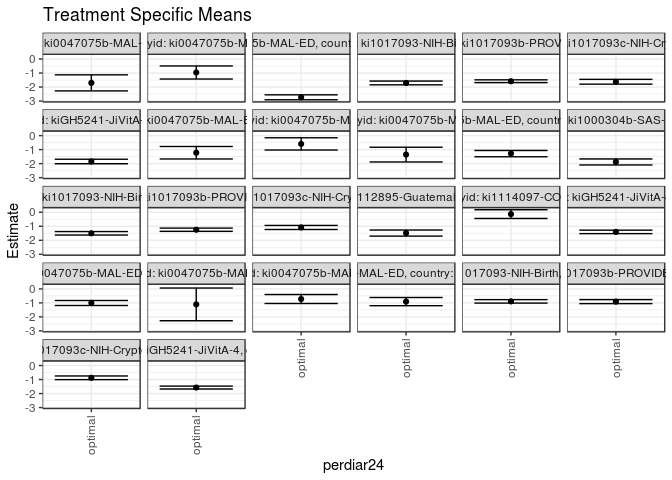

## Results Table

### Parameter: TSM

| agecat | studyid | country | intervention_level | baseline_level | estimate | ci_lower | ci_upper |
| --- | --- | --- | --- | --- | --- | --- | --- |
| Birth | ki0047075b-MAL-ED | BANGLADESH | optimal | observed | -1.0059818 | -1.1846643 | -0.8272994 |
| Birth | ki0047075b-MAL-ED | INDIA | optimal | observed | -1.1048457 | -2.2729982 | 0.0633068 |
| Birth | ki0047075b-MAL-ED | PERU | optimal | observed | -0.7223530 | -1.0427577 | -0.4019482 |
| Birth | ki0047075b-MAL-ED | TANZANIA, UNITED REPUBLIC OF | optimal | observed | -0.9059116 | -1.1981371 | -0.6136861 |
| Birth | ki1017093-NIH-Birth | BANGLADESH | optimal | observed | -0.8905641 | -1.0139753 | -0.7671528 |
| Birth | ki1017093b-PROVIDE | BANGLADESH | optimal | observed | -0.9087754 | -1.0530731 | -0.7644778 |
| Birth | ki1017093c-NIH-Crypto | BANGLADESH | optimal | observed | -0.8765127 | -1.0068232 | -0.7462023 |
| Birth | kiGH5241-JiVitA-4 | BANGLADESH | optimal | observed | -1.5713327 | -1.6755321 | -1.4671334 |
| 6 months | ki0047075b-MAL-ED | BANGLADESH | optimal | observed | -1.2218813 | -1.6669371 | -0.7768255 |
| 6 months | ki0047075b-MAL-ED | NEPAL | optimal | observed | -0.5899350 | -1.0270116 | -0.1528584 |
| 6 months | ki0047075b-MAL-ED | PERU | optimal | observed | -1.3528256 | -1.8783136 | -0.8273375 |
| 6 months | ki0047075b-MAL-ED | TANZANIA, UNITED REPUBLIC OF | optimal | observed | -1.2825920 | -1.5071186 | -1.0580655 |
| 6 months | ki1000304b-SAS-FoodSuppl | INDIA | optimal | observed | -1.8789799 | -2.0944471 | -1.6635128 |
| 6 months | ki1017093-NIH-Birth | BANGLADESH | optimal | observed | -1.5020637 | -1.6264764 | -1.3776509 |
| 6 months | ki1017093b-PROVIDE | BANGLADESH | optimal | observed | -1.2457468 | -1.3612394 | -1.1302543 |
| 6 months | ki1017093c-NIH-Crypto | BANGLADESH | optimal | observed | -1.0848428 | -1.2310646 | -0.9386211 |
| 6 months | ki1112895-Guatemala BSC | GUATEMALA | optimal | observed | -1.4850724 | -1.7014341 | -1.2687107 |
| 6 months | ki1114097-CONTENT | PERU | optimal | observed | -0.1305096 | -0.4423261 | 0.1813070 |
| 6 months | kiGH5241-JiVitA-4 | BANGLADESH | optimal | observed | -1.4009662 | -1.5259531 | -1.2759793 |
| 24 months | ki0047075b-MAL-ED | BANGLADESH | optimal | observed | -1.7027911 | -2.2754621 | -1.1301201 |
| 24 months | ki0047075b-MAL-ED | NEPAL | optimal | observed | -0.9627589 | -1.4294289 | -0.4960889 |
| 24 months | ki0047075b-MAL-ED | TANZANIA, UNITED REPUBLIC OF | optimal | observed | -2.7344394 | -2.9104579 | -2.5584210 |
| 24 months | ki1017093-NIH-Birth | BANGLADESH | optimal | observed | -1.7087875 | -1.8426677 | -1.5749072 |
| 24 months | ki1017093b-PROVIDE | BANGLADESH | optimal | observed | -1.5858869 | -1.6840687 | -1.4877050 |
| 24 months | ki1017093c-NIH-Crypto | BANGLADESH | optimal | observed | -1.6250101 | -1.7975978 | -1.4524223 |
| 24 months | kiGH5241-JiVitA-4 | BANGLADESH | optimal | observed | -1.8445321 | -2.0054363 | -1.6836279 |

### Parameter: E(Y)

| agecat | studyid | country | intervention_level | baseline_level | estimate | ci_lower | ci_upper |
| --- | --- | --- | --- | --- | --- | --- | --- |
| Birth | ki0047075b-MAL-ED | BANGLADESH | observed | observed | -1.1180952 | -1.2525408 | -0.9836496 |
| Birth | ki0047075b-MAL-ED | INDIA | observed | observed | -1.2036170 | -1.4976814 | -0.9095527 |
| Birth | ki0047075b-MAL-ED | PERU | observed | observed | -0.8827897 | -1.0001058 | -0.7654736 |
| Birth | ki0047075b-MAL-ED | TANZANIA, UNITED REPUBLIC OF | observed | observed | -1.1556000 | -1.3655361 | -0.9456639 |
| Birth | ki1017093-NIH-Birth | BANGLADESH | observed | observed | -0.9314050 | -1.0202164 | -0.8425936 |
| Birth | ki1017093b-PROVIDE | BANGLADESH | observed | observed | -0.8851020 | -0.9601332 | -0.8100709 |
| Birth | ki1017093c-NIH-Crypto | BANGLADESH | observed | observed | -0.9094945 | -0.9809370 | -0.8380521 |
| Birth | kiGH5241-JiVitA-4 | BANGLADESH | observed | observed | -1.5232908 | -1.5723277 | -1.4742539 |
| 6 months | ki0047075b-MAL-ED | BANGLADESH | observed | observed | -1.2054910 | -1.3228953 | -1.0880867 |
| 6 months | ki0047075b-MAL-ED | NEPAL | observed | observed | -0.5610593 | -0.6737915 | -0.4483272 |
| 6 months | ki0047075b-MAL-ED | PERU | observed | observed | -1.3280952 | -1.4363364 | -1.2198541 |
| 6 months | ki0047075b-MAL-ED | TANZANIA, UNITED REPUBLIC OF | observed | observed | -1.3687449 | -1.4907629 | -1.2467270 |
| 6 months | ki1000304b-SAS-FoodSuppl | INDIA | observed | observed | -1.8986842 | -2.0118892 | -1.7854792 |
| 6 months | ki1017093-NIH-Birth | BANGLADESH | observed | observed | -1.4073821 | -1.4960598 | -1.3187043 |
| 6 months | ki1017093b-PROVIDE | BANGLADESH | observed | observed | -1.0916915 | -1.1661176 | -1.0172654 |
| 6 months | ki1017093c-NIH-Crypto | BANGLADESH | observed | observed | -1.1986783 | -1.2700937 | -1.1272630 |
| 6 months | ki1112895-Guatemala BSC | GUATEMALA | observed | observed | -1.5619008 | -1.6727702 | -1.4510313 |
| 6 months | ki1114097-CONTENT | PERU | observed | observed | -0.3139217 | -0.4868486 | -0.1409948 |
| 6 months | kiGH5241-JiVitA-4 | BANGLADESH | observed | observed | -1.3447940 | -1.3820261 | -1.3075620 |
| 24 months | ki0047075b-MAL-ED | BANGLADESH | observed | observed | -1.9789151 | -2.1055330 | -1.8522972 |
| 24 months | ki0047075b-MAL-ED | NEPAL | observed | observed | -1.3118640 | -1.4315132 | -1.1922149 |
| 24 months | ki0047075b-MAL-ED | TANZANIA, UNITED REPUBLIC OF | observed | observed | -2.6451636 | -2.7802323 | -2.5100948 |
| 24 months | ki1017093-NIH-Birth | BANGLADESH | observed | observed | -2.2190579 | -2.3217459 | -2.1163699 |
| 24 months | ki1017093b-PROVIDE | BANGLADESH | observed | observed | -1.6024221 | -1.6857420 | -1.5191023 |
| 24 months | ki1017093c-NIH-Crypto | BANGLADESH | observed | observed | -1.4412646 | -1.5249156 | -1.3576135 |
| 24 months | kiGH5241-JiVitA-4 | BANGLADESH | observed | observed | -1.7807218 | -1.8162478 | -1.7451958 |

### Parameter: PAR

| agecat | studyid | country | intervention_level | baseline_level | estimate | ci_lower | ci_upper |
| --- | --- | --- | --- | --- | --- | --- | --- |
| Birth | ki0047075b-MAL-ED | BANGLADESH | optimal | observed | -0.1121134 | -0.2369353 | 0.0127084 |
| Birth | ki0047075b-MAL-ED | INDIA | optimal | observed | -0.0987714 | -1.2270988 | 1.0295561 |
| Birth | ki0047075b-MAL-ED | PERU | optimal | observed | -0.1604367 | -0.4601795 | 0.1393060 |
| Birth | ki0047075b-MAL-ED | TANZANIA, UNITED REPUBLIC OF | optimal | observed | -0.2496884 | -0.5520736 | 0.0526968 |
| Birth | ki1017093-NIH-Birth | BANGLADESH | optimal | observed | -0.0408409 | -0.1402794 | 0.0585976 |
| Birth | ki1017093b-PROVIDE | BANGLADESH | optimal | observed | 0.0236734 | -0.1075171 | 0.1548639 |
| Birth | ki1017093c-NIH-Crypto | BANGLADESH | optimal | observed | -0.0329818 | -0.1446285 | 0.0786649 |
| Birth | kiGH5241-JiVitA-4 | BANGLADESH | optimal | observed | 0.0480419 | -0.0476135 | 0.1436974 |
| 6 months | ki0047075b-MAL-ED | BANGLADESH | optimal | observed | 0.0163903 | -0.4328211 | 0.4656016 |
| 6 months | ki0047075b-MAL-ED | NEPAL | optimal | observed | 0.0288757 | -0.3960100 | 0.4537613 |
| 6 months | ki0047075b-MAL-ED | PERU | optimal | observed | 0.0247303 | -0.4970256 | 0.5464862 |
| 6 months | ki0047075b-MAL-ED | TANZANIA, UNITED REPUBLIC OF | optimal | observed | -0.0861529 | -0.2885682 | 0.1162624 |
| 6 months | ki1000304b-SAS-FoodSuppl | INDIA | optimal | observed | -0.0197043 | -0.2252697 | 0.1858611 |
| 6 months | ki1017093-NIH-Birth | BANGLADESH | optimal | observed | 0.0946816 | 0.0046962 | 0.1846671 |
| 6 months | ki1017093b-PROVIDE | BANGLADESH | optimal | observed | 0.1540553 | 0.0618732 | 0.2462375 |
| 6 months | ki1017093c-NIH-Crypto | BANGLADESH | optimal | observed | -0.1138355 | -0.2494974 | 0.0218264 |
| 6 months | ki1112895-Guatemala BSC | GUATEMALA | optimal | observed | -0.0768284 | -0.2796016 | 0.1259448 |
| 6 months | ki1114097-CONTENT | PERU | optimal | observed | -0.1834121 | -0.4456720 | 0.0788478 |
| 6 months | kiGH5241-JiVitA-4 | BANGLADESH | optimal | observed | 0.0561721 | -0.0631123 | 0.1754566 |
| 24 months | ki0047075b-MAL-ED | BANGLADESH | optimal | observed | -0.2761240 | -0.8488974 | 0.2966494 |
| 24 months | ki0047075b-MAL-ED | NEPAL | optimal | observed | -0.3491051 | -0.8083272 | 0.1101169 |
| 24 months | ki0047075b-MAL-ED | TANZANIA, UNITED REPUBLIC OF | optimal | observed | 0.0892759 | -0.0276648 | 0.2062165 |
| 24 months | ki1017093-NIH-Birth | BANGLADESH | optimal | observed | -0.5102704 | -0.6765725 | -0.3439684 |
| 24 months | ki1017093b-PROVIDE | BANGLADESH | optimal | observed | -0.0165353 | -0.0752253 | 0.0421547 |
| 24 months | ki1017093c-NIH-Crypto | BANGLADESH | optimal | observed | 0.1837455 | 0.0370321 | 0.3304588 |
| 24 months | kiGH5241-JiVitA-4 | BANGLADESH | optimal | observed | 0.0638103 | -0.0922492 | 0.2198698 |